# conseguiR: A Lightweight Object-First Walkthrough

The conseguiR authors

17 April 2026

# Contents

```r
library(conseguiR)
library(data.table)
library(igraph)
```

# 1 Overview

`conseguiR` is designed as an object-first workflow for integrating:

- germline evidence
- somatic evidence
- epigenomic evidence

onto a gene-regulatory graph.

In a full analysis, those three evidence streams are combined, imposed onto a backend graph, propagated by diffusion, and then distilled into smaller interpretable outputs such as score plots, locus plots, and selected gene-gene subgraphs.

This vignette deliberately uses a **tiny in-memory toy example** rather than large real study files. The goal here is to show how the package behaves as an R package:

- compute stages return objects
- plots can be generated from those objects
- external tools such as MAGMA and Python-backed diffusion are additional runtime stages, not the only way to understand the package API

# 2 The object-first idea

The highest-level package design is:

1. validate inputs
2. compute modality-specific score objects
3. build a scored graph object
4. optionally run downstream diffusion and subgraph calling
5. visualize intermediate or downstream objects

The important package behavior is that intermediate compute stages return bundles in memory by default. Users do not need to create a pile of files just to move from one stage to the next.

# 3 A tiny validation example

We start with minimal in-memory GWAS-like and somatic inputs. This is enough to demonstrate the lightweight validation layer.

```r
toy_gwas <- data.table(
  variant_id = c("rs1", "rs2", "rs3"),
  chromosome = c("1", "1", "1"),
  base_pair_location = c(101L, 220L, 340L),
  p_value = c(0.05, 1e-4, 0.2)
)

toy_somatic <- data.table(
  sample_id = c("S1", "S2", "S2"),
  chromosome = c("1", "1", "1"),
  start_position = c(105L, 230L, 360L),
  end_position = c(105L, 230L, 360L),
  ref = c("A", "G", "C"),
  alt = c("T", "A", "T")
)

validation <- validate_inputs(
  gwas_sumstats = toy_gwas,
  somatic_maf = toy_somatic,
  verbose = FALSE
)

validation$bundle_type
```

```
#> [1] "validation"
```

This answers a modest but important question: are the supplied objects structured well enough for the package to start working with them?

# 4 Building a tiny scored graph

For the rest of the vignette we create a tiny toy gene-regulatory graph in memory. This avoids heavy external dependencies while still exercising the package’s graph-scoring interface.

```r
toy_vertices <- data.frame(
  name = c("MYC", "BCL2", "GH01J000001", "GH01J000002"),
  node_id = c("MYC", "BCL2", "GH01J000001", "GH01J000002"),
  node_type = c("gene", "gene", "reg", "reg"),
  stringsAsFactors = FALSE
)

toy_edges <- data.frame(
  from = c("GH01J000001", "GH01J000001", "GH01J000002"),
  to = c("MYC", "BCL2", "MYC"),
  confidence = c(0.9, 0.6, 0.8),
  stringsAsFactors = FALSE
)

toy_graph <- graph_from_data_frame(
  d = toy_edges,
  vertices = toy_vertices,
  directed = TRUE
)
```

Now we create tiny modality-specific score tables. These are not meant to be biologically meaningful; they are just enough to show the API contract.

```r
toy_gene_germline <- data.table(
  gene_id = c("MYC", "BCL2"),
  zstat = c(3.2, 1.4)
)

toy_reg_germline <- data.table(
  reg_elem_id = c("GH01J000001", "GH01J000002"),
  zstat = c(2.6, 1.1)
)

toy_gene_somatic <- data.table(
  gene_id = c("MYC", "BCL2"),
  zstat = c(1.8, -0.9),
  p_value = c(0.02, 0.4)
)

toy_reg_somatic <- data.table(
  reg_elem_id = c("GH01J000001", "GH01J000002"),
  zstat = c(0.7, -0.4),
  p_value = c(0.3, 0.7)
)

toy_reg_epigenomic <- data.table(
  reg_elem_id = c("GH01J000001", "GH01J000002"),
  zstat = c(2.1, 0.3)
)
```

The scored-graph stage accepts either full score bundles from earlier package stages or explicit score tables. Here we use the explicit table route.

```r
scored_graph <- build_scored_gene_reg_graph(
  graph = toy_graph,
  gene_germline_scores = toy_gene_germline,
  reg_germline_scores = toy_reg_germline,
  gene_somatic_scores = toy_gene_somatic,
  reg_somatic_scores = toy_reg_somatic,
  reg_epigenomic_scores = toy_reg_epigenomic,
  save_outputs = FALSE,
  verbose = FALSE
)

scored_graph$bundle_type
```

```
#> [1] "scored_gene_reg_graph"
```

The returned bundle contains the scored graph object plus the scored node and edge tables.

```r
scored_graph$objects$nodes[, .(
  node_id,
  node_type,
  germline_score,
  somatic_score,
  epigenomic_score
)]
```

```
#>        node_id node_type germline_score somatic_score epigenomic_score
#>         <char>    <char>          <num>         <num>            <num>
#> 1:        BCL2      gene            1.4          -0.9              0.0
#> 2:         MYC      gene            3.2           1.8              0.0
#> 3: GH01J000001       reg            2.6           0.7              2.1
#> 4: GH01J000002       reg            1.1          -0.4              0.3
```

This is the core pre-diffusion integration step:

- genes receive germline and somatic scores
- regulatory elements receive germline, somatic, and epigenomic scores
- missing modalities are filled with zeros rather than silently dropping nodes

# 5 Plotting score objects

Because plotting functions accept bundles and tables directly, users can inspect intermediate results without first saving anything to disk.

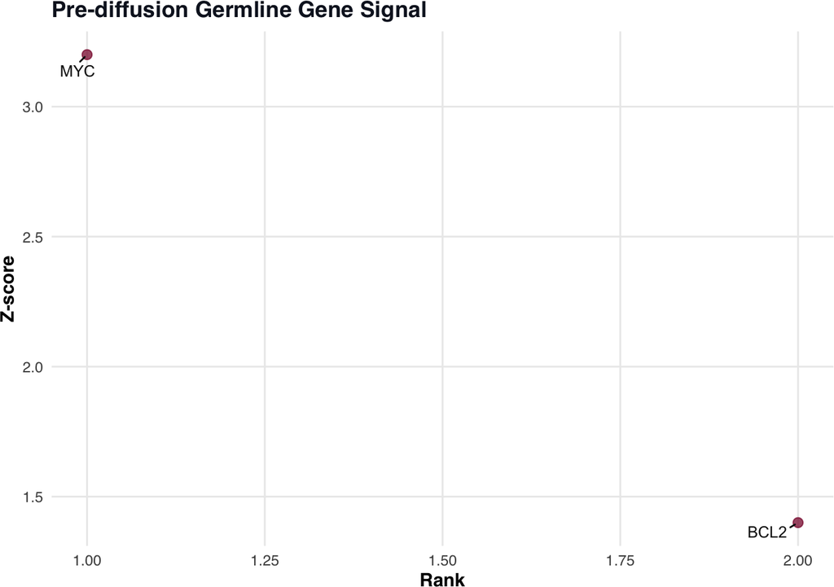

```r
germline_gene_plot <- plot_germline_gene_scores(
  scored_graph = scored_graph,
  stage = "pre",
  label_features = c("MYC", "BCL2"),
  save_plot = FALSE
)

germline_gene_plot$plot
```

We can do the same for the regulatory epigenomic scores.

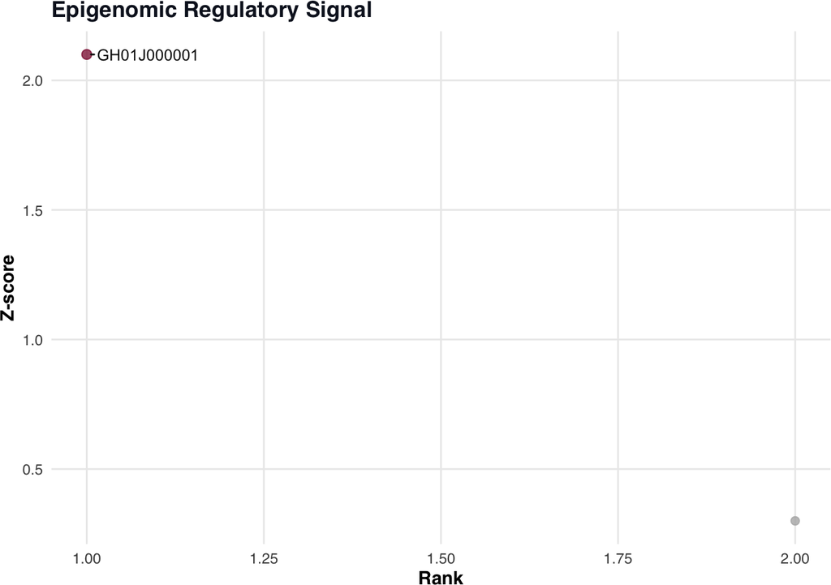

```r
epigenomic_reg_plot <- plot_epigenomic_reg_scores(
  scored_graph = scored_graph,
  label_features = c("GH01J000001"),
  save_plot = FALSE
)

epigenomic_reg_plot$plot
```

This demonstrates an important package pattern: plotting can happen straight from in-memory bundle objects, and file output is optional.

# 6 Runtime-aware stages

Some package stages depend on additional external runtimes:

- MAGMA for germline scoring from real GWAS data
- managed Python via `basilisk` for diffusion and selected-subgraph calling

The runtime check helper tells us whether those heavier stages are currently available.

```r
runtime_status <- check_conseguiR_runtime(quiet = TRUE)

list(
  core_ok = runtime_status$core_ok,
  python_stage_ok = runtime_status$python_stage_ok,
  magma_ok = runtime_status$magma_ok
)
```

```
#> $core_ok
#> [1] FALSE
#>
#> $python_stage_ok
#> [1] FALSE
#>
#> $magma_ok
#> [1] FALSE
```

That lets users decide whether they can proceed directly into the full pipeline or whether they first need to install MAGMA or allow the Python-backed stages to provision.

# 7 Full pipeline shape

In a real analysis, the intended high-level sequence is still:

```r
germline_scores <- prepare_germline_scores(...)
somatic_scores <- prepare_somatic_scores(...)
epigenomic_scores <- prepare_epigenomic_scores(...)

scored_graph <- build_scored_gene_reg_graph(
  germline_scores = germline_scores,
  somatic_scores = somatic_scores,
  epigenomic_scores = epigenomic_scores
)

diffusion <- run_gene_reg_diffusion(scored_graph = scored_graph)
selected_subgraph <- call_selected_subgraph(diffusion = diffusion)
```

Those stages are not run in this lightweight vignette because they depend on external tools and real study-scale inputs. The toy example above focuses on what the package itself contributes most directly:

- object-oriented handoff between stages
- graph-based score integration
- bundle-driven plotting

# 8 Conclusion

This toy walkthrough is intentionally small, but it captures the core package philosophy:

- `conseguiR` works with in-memory objects, not just files
- graph scoring is a first-class stage in the workflow
- visualization functions can inspect intermediate objects directly
- heavier external-runtime stages are layered on top of that object-first base

That makes the package easier to debug, easier to script, and easier to extend to real germline, somatic, and epigenomic analyses once the relevant runtimes and study files are available.